# __EEG-based Brain-Computer Interface__

#### Boulkhir Zakaria, Ikne Omar

#### February 20th, 2021

### ■ **Overview**

##### [Overview](https://www.kaggle.com/c/eeg-based-brain-computer-interface/overview)

### ■ **Libraries**

```python
## to handle vectors & matrices
import numpy as np

## to plot
import matplotlib.pyplot as plt
from mpl_toolkits import mplot3d
import seaborn as sns

## to handle dataframes
import pandas as pd


import math as m

from tqdm import tqdm
from scipy.interpolate import griddata, interp1d

## sklearn dependencies
from sklearn.model_selection import train_test_split
from sklearn.preprocessing import scale
from sklearn.metrics import mean_absolute_error
from sklearn.ensemble import RandomForestClassifier
from sklearn.model_selection import GridSearchCV

## tf dependencies
import tensorflow as tf
from tensorflow import keras
```

### ■ **Load & Prepare Data**

```
The dimension of the training set is    : (2136, 64, 3)
The dimension of the training labels is : (2136,)
The dimension of the testing set is     : (533, 64, 3)
```

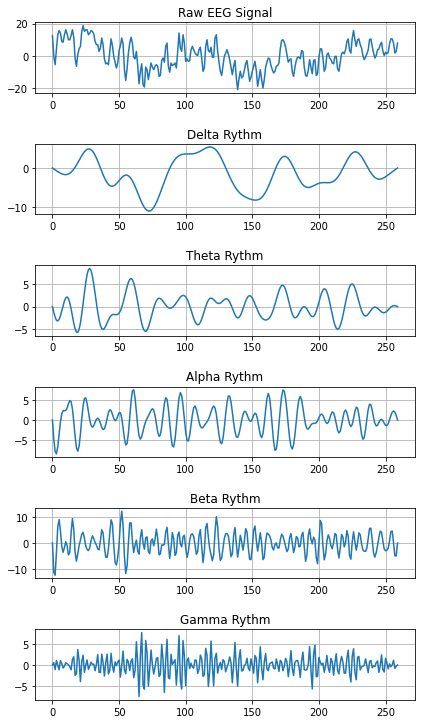

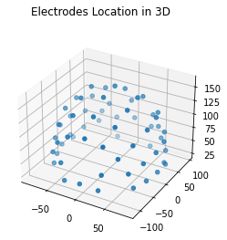

```
Image Creation
```

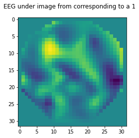

```python
def band_image(frequency_band, electrodes_location, img_size=32):
    """"""
    locs_2d = elec_proj( electrodes_location )
    frequency_band = frequency_band / np.min( frequency_band )
    frequency_band = frequency_band.reshape( (frequency_band.shape[0], -1) )

    images = image_generation( frequency_band, locs_2d, img_size )
    return images

def elec_proj(loc_3d):
    """"""
    locs_2d = []
    for l in loc_3d:
        locs_2d.append( azim_proj( l ) )
    return np.asarray( locs_2d )

def azim_proj(pos):
    """"""
    [r, elev, az] = cart2sph( pos[0], pos[1], pos[2] )

    return pol2cart( az, m.pi / 2 - elev )

def pol2cart(theta, rho):
    """"""
    return rho * m.cos( theta ), rho * m.sin( theta )

def cart2sph(x, y, z):
    """"""
    x2_y2 = x ** 2 + y ** 2
    r = m.sqrt( x2_y2 + z ** 2 )  # r
    elev = m.atan2( z, m.sqrt( x2_y2 ) )  # Elevation
    az = m.atan2( y, x )  # Azimuth
    return r, elev, az

def image_generation(feature_matrix, electrodes_loc, n_gridpoints):
    """"""
    n_electrodes = electrodes_loc.shape[0]  # number of electrodes
    n_bands = feature_matrix.shape[1] // n_electrodes  # number of frequency bands considered in the feature matrix
    n_samples = feature_matrix.shape[0]  # number of samples to consider in the feature matrix.

    ## Checking the dimension of the feature matrix
    if feature_matrix.shape[1] % n_electrodes != 0:
        print( 'The combination feature matrix - electrodes locations is not working.' )
    assert feature_matrix.shape[1] % n_electrodes == 0
    new_feat = []

    ## Reshape a novel feature matrix with a list of array with shape [n_samples x n_electrodes] for each frequency band
    for bands in range( n_bands ):
        new_feat.append( feature_matrix[:, bands * n_electrodes: (bands + 1) * n_electrodes] )

    ## Creation of a meshgrid data interpolation
    ## Creation of an empty grid
    grid_x, grid_y = np.mgrid[
                     np.min( electrodes_loc[:, 0] ): np.max( electrodes_loc[:, 0] ): n_gridpoints * 1j,  # along x_axis
                     np.min( electrodes_loc[:, 1] ): np.max( electrodes_loc[:, 1] ): n_gridpoints * 1j  # along y_axis
                     ]

    interpolation_img = []
    ## Interpolation
    ## Creation of the empty interpolated feature matrix
    for bands in range( n_bands ):
        interpolation_img.append( np.zeros( [n_samples, n_gridpoints, n_gridpoints] ) )
    ## Interpolation between the points
    ## print('Signals interpolations.')
    for sample in tqdm( range( n_samples ) ):
        for bands in range( n_bands ):
            interpolation_img[bands][sample, :, :] = griddata( electrodes_loc, new_feat[bands][sample, :],
                                                               (grid_x, grid_y), method='cubic', fill_value=np.nan )
    ## Normalization - replacing the nan values by interpolation
    for bands in range( n_bands ):
        interpolation_img[bands][~np.isnan( interpolation_img[bands] )] = scale(
            interpolation_img[bands][~np.isnan( interpolation_img[bands] )] )
        interpolation_img[bands] = np.nan_to_num( interpolation_img[bands] )
    return np.swapaxes( np.asarray( interpolation_img ), 0, 1 )  # swap axes to have [samples, colors, W, H]

sig = np.load('eeg-based-brain-computer-interface/sig.npy')

info = ['Raw EEG Signal', 'Delta Rythm', 'Theta Rythm', 'Alpha Rythm',
        'Beta Rythm', 'Gamma Rythm']

## Display of the five rythms + the initial EEG
fig, ax = plt.subplots(6, figsize=(6,10))
fig.tight_layout(h_pad=3)
for i in range(6):
    ax[i].plot(sig[i])
    ax[i].set_title(info[i])
    ax[i].grid()

## upload the datsets
X_train = np.load('eeg-based-brain-computer-interface/X_train.npy')
y_train = np.load('eeg-based-brain-computer-interface/y_train.npy')
print('The dimension of the training set is    :', X_train.shape)
print('The dimension of the training labels is :', y_train.shape)

X_test = np.load('eeg-based-brain-computer-interface/X_test.npy')
print('The dimension of the testing set is     :', X_test.shape)


## Display of 3D position of each electrodes
channel_information = np.load('eeg-based-brain-computer-interface/ChanInfo.npy', allow_pickle=True).all()

fig = plt.figure()
ax = plt.axes(projection="3d")

ax.scatter3D(channel_information['position'][:, 0], channel_information['position'][:, 1], channel_information['position'][:, 2])
plt.suptitle("Electrodes Location in 3D")
plt.show()

## Image Creation
print('Image Creation')
Electrodes_position = channel_information['position']
X_image_train = band_image(X_train, Electrodes_position)
X_image_test = band_image(X_test, Electrodes_position)

## command specific to keras (need to have n_channels x Height x Width as shape)
## implementation made with pytorch wich is a clearly better lib ;)
X_image_train = X_image_train.swapaxes(1,-1)
X_image_test = X_image_test.swapaxes(1,-1)

plt.imshow(X_image_train[584, :, :, 0])
plt.suptitle('EEG under image from corresponding to a '+str(y_train[584]))
plt.show()
```

### ■ **Data Processing**

#### Correlation

Here we will compute the correlation between rythmes & classes to get an idea about the effect of each rhythm on the classes.

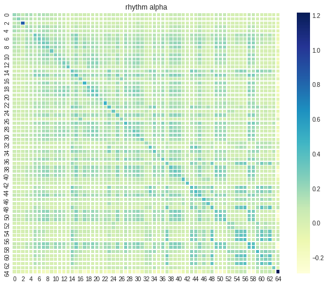

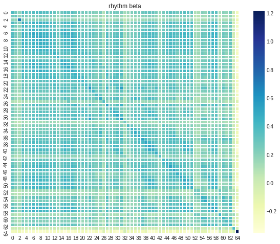

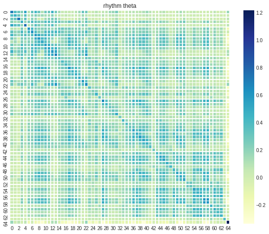

```python
## set plotting style
plt.style.use('seaborn-whitegrid')

## different rhythmes
rhythmes = ['alpha', 'beta', 'theta']

## resize plot
plt.rcParams['figure.figsize'] = [10, 8]

## plot heatmap
for i in range(X_train.shape[2]):
    sns.heatmap(np.cov(X_train[:, :, i].T, y_train), linewidths=.5, cmap="YlGnBu")
    plt.title(f'rhythm {rhythmes[i]}')
    plt.show()
```

**Note :**

- The rhythm $\beta$ is more correlated with outputs more that $\alpha$ and $\beta$, which is logical since $\beta$ corresponds to physical activity, movment and excitation, while $\alpha$ & $\beta$ correspond to memory and relaxation tasks.

#### Split data

```python
## split data
train_X, test_X, train_y, test_y = train_test_split(X_train, y_train, train_size=.85)

print('The shape of the new training data :', train_X.shape)
print('The shape of the new test data     :', test_X.shape)
```

[output not shown]

### ■ **First Approach : Convolutional Neural Network**

In this first approach we will build a classical convolutional neural network, since the format of the data correspond to the format of "images", we can make an analogy between $(\alpha, \beta, \theta)$ and $(R, G, B)$.

#### Reshape & Normalize Data

```python
## reshape the data
X_train = X_train.reshape((X_train.shape[0], 64, 3, 1))
X_test  = X_test.reshape((X_test.shape[0], 64, 3, 1))

## normalize data
X_train = keras.utils.normalize(X_train, axis=1)
X_test  = keras.utils.normalize(X_test, axis=1)

## transform labels to binary representation matrices
y_train_cat = keras.utils.to_categorical(y_train)
train_y_cat = keras.utils.to_categorical(train_y)
```

#### Build the model

```python
cnn = keras.Sequential([
    keras.layers.Conv2D(32, (3, 3), activation='relu', kernel_initializer='he_uniform', input_shape=(64, 3, 1)),
    keras.layers.MaxPooling2D((2, 2), padding='same'),
    keras.layers.Conv2D(64, (3, 1), activation='relu', kernel_initializer='he_uniform', input_shape=(64, 3, 1)),
    keras.layers.MaxPooling2D((2, 2), padding='same'),
    keras.layers.Flatten(),
    keras.layers.Dense(100, activation='relu', kernel_initializer='he_uniform'),
    keras.layers.Dense(5, activation='softmax'),
])

cnn.compile(optimizer='adam', loss='categorical_crossentropy', metrics=['accuracy'])
cnn.summary()
```

```
Model: "sequential"
_________________________________________________________________
Layer (type)                 Output Shape              Param #
=================================================================
conv2d (Conv2D)              (None, 62, 1, 32)         320
_________________________________________________________________
max_pooling2d (MaxPooling2D) (None, 31, 1, 32)         0
_________________________________________________________________
conv2d_1 (Conv2D)            (None, 29, 1, 64)         6208
_________________________________________________________________
max_pooling2d_1 (MaxPooling2 (None, 15, 1, 64)         0
_________________________________________________________________
flatten (Flatten)            (None, 960)               0
_________________________________________________________________
dense (Dense)                (None, 100)               96100
_________________________________________________________________
dense_1 (Dense)              (None, 5)                 505
=================================================================
Total params: 103,133
Trainable params: 103,133
Non-trainable params: 0
_________________________________________________________________
```

#### fit the model

```python
## parameters
n_epochs = 100
batch_size = 32

## fit the model
%time history = cnn.fit(X_train, y_train_cat, epochs=n_epochs, batch_size=batch_size, verbose=0)
```

```
CPU times: user 1min 7s, sys: 7.57 s, total: 1min 15s
Wall time: 34.9 s
```

#### Accuracy & Loss

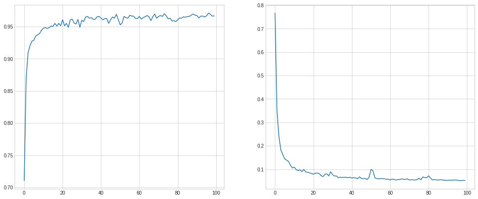

```python
## resize plot
plt.rcParams['figure.figsize'] = [17, 7]

# convert the training history to a dataframe
history_df = pd.DataFrame(history.history)

## create subplot
fig, (ax1, ax2) = plt.subplots(nrows=1, ncols=2)

## plot accuracy & loss
ax1.plot(history_df['accuracy'])
ax2.plot(history_df['loss'])

plt.show()
```

#### Using splitted Data

```python
cnn = keras.Sequential([
    keras.layers.Conv2D(32, (3, 3), activation='relu', kernel_initializer='he_uniform', input_shape=(64, 3, 1)),
    keras.layers.MaxPooling2D((2, 2), padding='same'),
    keras.layers.Conv2D(64, (3, 1), activation='relu', kernel_initializer='he_uniform', input_shape=(64, 3, 1)),
    keras.layers.MaxPooling2D((2, 2), padding='same'),
    keras.layers.Flatten(),
    keras.layers.Dense(100, activation='relu', kernel_initializer='he_uniform'),
    keras.layers.Dense(5, activation='softmax'),
])

cnn.compile(optimizer='adam', loss='categorical_crossentropy', metrics=['accuracy'])


## fit the model
%time history = cnn.fit(train_X, train_y_cat, epochs=n_epochs, batch_size=batch_size, verbose=0)
```

```
CPU times: user 1min 1s, sys: 7.11 s, total: 1min 8s
Wall time: 32 s
```

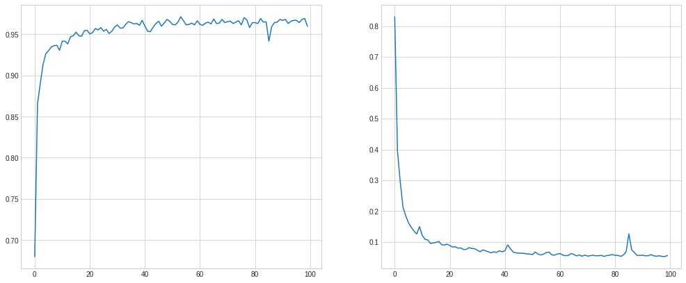

```python
## resize plot
plt.rcParams['figure.figsize'] = [17, 7]

# convert the training history to a dataframe
history_df = pd.DataFrame(history.history)

## create subplot
fig, (ax1, ax2) = plt.subplots(nrows=1, ncols=2)

## plot accuracy & loss
ax1.plot(history_df['accuracy'])
ax2.plot(history_df['loss'])

plt.show()
```

```python
## compute error
pred_y = cnn.predict_classes(test_X)
print('The mean absolute error :', mean_absolute_error(test_y, pred_y)
```

[output not shown]